# Managers

## Tidy Tuesday

This is my fifth contribution to TidyTuesday, which is ‘a weekly podcast and community activity brought to you by the R4DS Online Learning Community’. Their goal is to help R learners learn in real-world contexts.

For more information, visit the [TidyTuesday homepage](https://www.tidytuesday.com/), check out their [GitHub repository](https://github.com/rfordatascience/tidytuesday) and follow the [R4DS Learning Community on Twitter](https://twitter.com/R4DScommunity).

The purpose of these posts is mainly for exercising purposes. Thus, the provided graphs are not necessarily designed to provide the greatest possible insights. However, I always provide the R code for interested people at the page bottom.

## Ask a Manager Survey

This week’s data comes from [Ask a Manager Survey](https://docs.google.com/spreadsheets/d/1IPS5dBSGtwYVbjsfbaMCYIWnOuRmJcbequohNxCyGVw/edit?resourcekey#gid=1625408792).

### Influence of Experience on annual salary

One could expect that the more experience a manager has in the relevant field, the higher her salary will be. I thus provide a bivariate descriptive plot to gain some first insights. To see the distribution in each class in more detail, I provide violin plots.

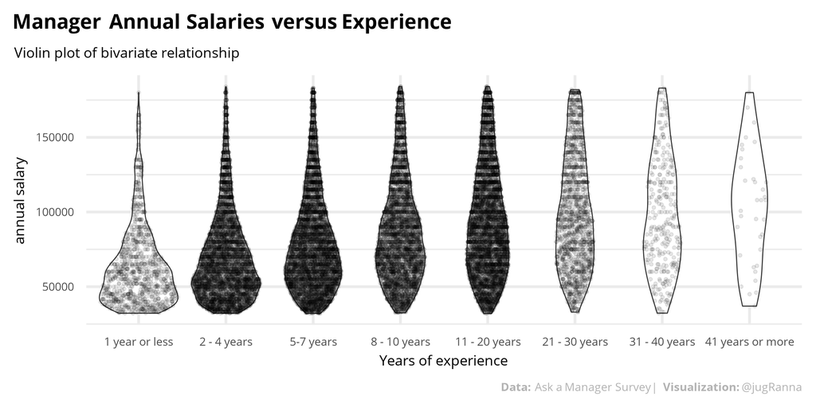

In general, as expected, years of experience seems to be positively associated with annual salaries of managers.

## References

- `ggtext`**-package**:  
  https://wilkelab.org/ggtext/
- `ggforce`**-package**:  
  https://ggforce.data-imaginist.com/
- `showtext`**-package**:  
  https://github.com/yixuan/showtext
- `tidyverse`**-package**:  
  https://www.tidyverse.org/

Full R code available on [Github](https://github.com/jgranna/tidytuesday/tree/main/2021-05-04).